# BRUCELLOSIS_RNASeq

EmilyScott

12/3/2019

## Differential Expression of Genes for Acute versus Chronic Brucellosis Patients

### Introduction

Brucellosis is a disease caused by bacterial pathogens Brucella melitensis (BM) and B. abortus. In humans, it manifests as Malta fever and in animals, another symptom is abortion. Patients diagnosed with Brucellosis have 4 outcome; acute diagnosis and treatment responsive, acute diagnosis and treatment unresponsive, chronic diagnosis and treatment responsive, chronic diagnosis and treatment unresponsive. This study will explore gene expression differences between acute brucellosis and chronic brucellosis to identify novel genes related to vastly differing diagnosis. The dataset “Refining brucellosis diagnosis by blood transcriptional profiling,” from recount2 will be used to identify these novel biomarkers because it has a large sample number and enough metadata to determine if there are any confounding variables. A whole blood RNAseq was completed on patients in Spain and Macedonia with brucellosis(n=105), healthy controls(n=47), (total n = 169). Long term data was collected on these patients by the Benaroya Research Institute to obtain their status as acute versus chronic brucellosis patient and treatment responder versus treatment non-responder. The Benaroya Research Institute published this study in an effort to refine brucellosis diagnosis by blood transcriptional profiling and determining important blood biomarkers. In my experiment, I will be using the characteristic variable diagnosis from their dataset to determine which samples were taken from patients with acute or chronic brucellosis.

In the world, 500000 new cases of brucellosis have been reported annually(Alavi, 2013). The effects of a brucellosis diagnosis are not to be taken for granted. Brucella has been tied to stress related genes (Zhang, 2009) and there was a woman who once developed chronic brucellosis that lasted for 19 years(Kawakami, 2019). Brucellosis has also been linked to an increased severity and possibly onset of acute pancreatitis(Suvak, 2016). In some rare cases, human meningitis can be infected with brucella result in worsened diagnosis with epilepsy as a serious symptom(Li, 2019).

In the past, treatment of brucellosis has not been uniform, there has been controversy (Alavi, 2013). Part of the controversy is due to the fact that different types of brucellosis respond better to different treatments but overall in uncomplicated brucellosis, a doxycycline-aminoglycoside combination is the first choice. Another complication is the age of the patient. Patients eight years old or younger tend to respond better to cotrimoxazole plus rifampin.

I hypothesize that I will see a stress related gene expression difference between acute and chronic brucellosis diagnosis. Past research on the interaction between stress and brucellosis shows a molecular mechanism between stress response and bacterial virulence (Liu, 2015). I am expecting a large amount of genes that would normally activate when the body is attaced with bacteria. A number of white blood cell signaling genes due to the body fighting the brucella bacteria should be present but I also expect stress to be a factor in whether or not the body is successful in that effort.

### Coding

Load the libraries needed.

```r
## ----"load libraries", message = FALSE, warning = FALSE--------------------
suppressWarnings(suppressMessages(library("recount")))
suppressWarnings(suppressMessages(library("GenomicRanges")))
suppressWarnings(suppressMessages(library("limma")))
suppressWarnings(suppressMessages(library("edgeR")))
suppressWarnings(suppressMessages(library("DESeq2")))
suppressWarnings(suppressMessages(library("regionReport")))
suppressWarnings(suppressMessages(library("clusterProfiler")))
suppressWarnings(suppressMessages(library("org.Hs.eg.db")))
suppressWarnings(suppressMessages(library("gplots")))
suppressWarnings(suppressMessages(library("derfinder")))
suppressWarnings(suppressMessages(library("rtracklayer")))
suppressWarnings(suppressMessages(library("GenomicFeatures")))
suppressWarnings(suppressMessages(library("bumphunter")))
suppressWarnings(suppressMessages(library("derfinderPlot")))
suppressWarnings(suppressMessages(library("sessioninfo")))
suppressWarnings(suppressMessages(library("dplyr")))
suppressWarnings(suppressMessages(library("ggplot2")))
suppressWarnings(suppressMessages(library("pheatmap")))
suppressWarnings(suppressMessages(library("RColorBrewer")))
suppressWarnings(suppressMessages(library("clusterProfiler")))
suppressWarnings(suppressMessages(library("org.Hs.eg.db")))
```

### Import “Refining brucellosis diagnosis by blood transcriptional profiling” dataset from recount2

The instrument used here was Illumina HiSeq 2500, which is normally used for short reads.

```r
#Search for and load the brucellosis data from recount2
project_info<-abstract_search('brucellosis')
download_study(project_info$project)
```

```
## 2019-12-17 21:02:46 downloading file rse_gene.Rdata to SRP059172
```

```r
load(file.path(project_info$project, 'rse_gene.Rdata'))
#Browse the data online
browse_study(project_info$project)
```

### Explore Brucellosis Dataset

```r
#Look at recount data information using the following lines of code
#make sure there are 169 samples
dim(colData(rse_gene))
```

```
## [1] 169  21
```

```r
#GEO info for SRP059172
head(colData(rse_gene)$geo_accession)
```

```
## [1] "GSM1704351" "GSM1704350" "GSM1704349" "GSM1704348" "GSM1704347"
## [6] "GSM1704357"
```

```r
#Look at feature info using this
head(rowRanges(rse_gene))
```

```
## GRanges object with 6 ranges and 3 metadata columns:
##                      seqnames              ranges strand |
##                         <Rle>           <IRanges>  <Rle> |
##   ENSG00000000003.14     chrX 100627109-100639991      - |
##    ENSG00000000005.5     chrX 100584802-100599885      + |
##   ENSG00000000419.12    chr20   50934867-50958555      - |
##   ENSG00000000457.13     chr1 169849631-169894267      - |
##   ENSG00000000460.16     chr1 169662007-169854080      + |
##   ENSG00000000938.12     chr1   27612064-27635277      - |
##                                 gene_id bp_length          symbol
##                             <character> <integer> <CharacterList>
##   ENSG00000000003.14 ENSG00000000003.14      4535          TSPAN6
##    ENSG00000000005.5  ENSG00000000005.5      1610            TNMD
##   ENSG00000000419.12 ENSG00000000419.12      1207            DPM1
##   ENSG00000000457.13 ENSG00000000457.13      6883           SCYL3
##   ENSG00000000460.16 ENSG00000000460.16      5967        C1orf112
##   ENSG00000000938.12 ENSG00000000938.12      3474             FGR
##   -------
##   seqinfo: 25 sequences (1 circular) from an unspecified genome; no seqlengths
```

```r
#look at counts using this
head(assays(rse_gene)$counts)
```

[output not shown]

[output cut: 183 more lines]

```
## ENSG00000000938.12     319500     260445     284943     285695      26529
##                    SRR2052665 SRR2052664 SRR2052663 SRR2052662 SRR2052661
## ENSG00000000003.14         50          0        254        101        101
## ENSG00000000005.5           0          0          0          0          0
## ENSG00000000419.12       8286      15679      13127       7897       7939
## ENSG00000000457.13       8917      10233      11455      10930      11263
## ENSG00000000460.16       3158       4600       4554       4314       4185
## ENSG00000000938.12     328247     306157     232831     285145     259786
##                    SRR2052660 SRR2052659 SRR2052658 SRR2052657
## ENSG00000000003.14         51          0         51         51
## ENSG00000000005.5           0          0          0          0
## ENSG00000000419.12       6785       6649       8711       8045
## ENSG00000000457.13       6427       8793       8052       8776
## ENSG00000000460.16       2874       3233       3394       3268
## ENSG00000000938.12     292529     261899     251599     299230
```

```r
#look at sample metadata using this
head(colData(rse_gene))
```

```
## DataFrame with 6 rows and 21 columns
##                project      sample  experiment         run
##            <character> <character> <character> <character>
## SRR2052702   SRP059172   SRS954288  SRX1050128  SRR2052702
## SRR2052701   SRP059172   SRS954289  SRX1050127  SRR2052701
## SRR2052700   SRP059172   SRS954290  SRX1050126  SRR2052700
## SRR2052699   SRP059172   SRS954291  SRX1050125  SRR2052699
## SRR2052698   SRP059172   SRS954292  SRX1050124  SRR2052698
## SRR2052708   SRP059172   SRS954293  SRX1050134  SRR2052708
##            read_count_as_reported_by_sra reads_downloaded
##                                <integer>        <integer>
## SRR2052702                       9114489          9114489
## SRR2052701                       8710667          8710667
## SRR2052700                       8233416          8233416
## SRR2052699                       7463990          7463990
## SRR2052698                       9254570          9254570
## SRR2052708                       7861745          7861745
##            proportion_of_reads_reported_by_sra_downloaded paired_end
##                                                 <numeric>  <logical>
## SRR2052702                                              1      FALSE
## SRR2052701                                              1      FALSE
## SRR2052700                                              1      FALSE
## SRR2052699                                              1      FALSE
## SRR2052698                                              1      FALSE
## SRR2052708                                              1      FALSE
##            sra_misreported_paired_end mapped_read_count       auc
##                             <logical>         <integer> <numeric>
## SRR2052702                      FALSE           9038163 454873801
## SRR2052701                      FALSE           8655444 435656051
## SRR2052700                      FALSE           8188242 412008995
## SRR2052699                      FALSE           7426338 373805349
## SRR2052698                      FALSE           9203734 463379169
## SRR2052708                      FALSE           7784664 391603333
##            sharq_beta_tissue sharq_beta_cell_type
##                  <character>          <character>
## SRR2052702                NA                   NA
## SRR2052701                NA                   NA
## SRR2052700                NA                   NA
## SRR2052699                NA                   NA
## SRR2052698                NA                   NA
```

[output cut: 18 more lines]

```
##              <character> <character>
## SRR2052702 SRR2052702.bw      MK_047
## SRR2052701 SRR2052701.bw      MK_093
## SRR2052700 SRR2052700.bw      MK_086
## SRR2052699 SRR2052699.bw      MK_085
## SRR2052698 SRR2052698.bw      MK_082
## SRR2052708 SRR2052708.bw      MK_017
##                                                                                              characteristics
##                                                                                              <CharacterList>
## SRR2052702 group: Brucellosis,subgroup: Group 5a,history of brucellosis: Chronic brucellosis (<10 years),...
## SRR2052701                group: Brucellosis,subgroup: Group 1,history of brucellosis: Acute brucellosis,...
## SRR2052700                group: Brucellosis,subgroup: Group 1,history of brucellosis: Acute brucellosis,...
## SRR2052699                group: Brucellosis,subgroup: Group 1,history of brucellosis: Acute brucellosis,...
## SRR2052698                group: Brucellosis,subgroup: Group 3,history of brucellosis: Acute brucellosis,...
## SRR2052708                group: Brucellosis,subgroup: Group 1,history of brucellosis: Acute brucellosis,...
```

### Scale counts and Create Diagnosis Grouping

```r
#scale counts
rse_SRP059172<-scale_counts(rse_gene)
#take out the scaled counts with assays()$counts
counts<-assays(rse_SRP059172)$counts
#Filter out the lowly expressed genes using counts to get a TRUE/FALSE filter variable
filter<-rowMeans(counts)>0.6

#pull out the characteristics into geochar
geochar <- lapply(split(colData(rse_gene), seq_len(nrow(colData(rse_gene)))), geo_characteristics)
#make group column in scaled data using geochar
colData(rse_SRP059172)$group <- as.factor(ifelse(grepl('Acute brucellosis', (history<-sapply(geochar,"[", 3))), 'Acute', 'Chronic'))
colData(rse_SRP059172)$response<-as.factor(ifelse(grepl('Complete remission',(history<-sapply(geochar,"[", 4))),'Complete remission','Reinfection'))
```

### Exploratory Analysis for the Brucellosis Dataset

```r
#Look at recount data information using the following lines of code
#Look at feature info using this
head(rowRanges(rse_SRP059172))
```

```
## GRanges object with 6 ranges and 3 metadata columns:
##                      seqnames              ranges strand |
##                         <Rle>           <IRanges>  <Rle> |
##   ENSG00000000003.14     chrX 100627109-100639991      - |
##    ENSG00000000005.5     chrX 100584802-100599885      + |
##   ENSG00000000419.12    chr20   50934867-50958555      - |
##   ENSG00000000457.13     chr1 169849631-169894267      - |
##   ENSG00000000460.16     chr1 169662007-169854080      + |
##   ENSG00000000938.12     chr1   27612064-27635277      - |
##                                 gene_id bp_length          symbol
##                             <character> <integer> <CharacterList>
##   ENSG00000000003.14 ENSG00000000003.14      4535          TSPAN6
##    ENSG00000000005.5  ENSG00000000005.5      1610            TNMD
##   ENSG00000000419.12 ENSG00000000419.12      1207            DPM1
##   ENSG00000000457.13 ENSG00000000457.13      6883           SCYL3
##   ENSG00000000460.16 ENSG00000000460.16      5967        C1orf112
##   ENSG00000000938.12 ENSG00000000938.12      3474             FGR
##   -------
##   seqinfo: 25 sequences (1 circular) from an unspecified genome; no seqlengths
```

```r
#look at counts using this
head(assays(rse_SRP059172)$counts)
```

[output not shown]

[output cut: 183 more lines]

```
## ENSG00000000938.12      28197      24025      25882      25405      13987
##                    SRR2052665 SRR2052664 SRR2052663 SRR2052662 SRR2052661
## ENSG00000000003.14          5          0         23          9         10
## ENSG00000000005.5           0          0          0          0          0
## ENSG00000000419.12        756       1479       1193        683        809
## ENSG00000000457.13        814        965       1041        945       1148
## ENSG00000000460.16        288        434        414        373        427
## ENSG00000000938.12      29954      28873      21165      24650      26480
##                    SRR2052660 SRR2052659 SRR2052658 SRR2052657
## ENSG00000000003.14          6          0          5          5
## ENSG00000000005.5           0          0          0          0
## ENSG00000000419.12        816        662        846        844
## ENSG00000000457.13        773        875        782        921
## ENSG00000000460.16        346        322        330        343
## ENSG00000000938.12      35185      26075      24442      31389
```

```r
#look at sample metadata using this
head(colData(rse_SRP059172))
```

```
## DataFrame with 6 rows and 23 columns
##                project      sample  experiment         run
##            <character> <character> <character> <character>
## SRR2052702   SRP059172   SRS954288  SRX1050128  SRR2052702
## SRR2052701   SRP059172   SRS954289  SRX1050127  SRR2052701
## SRR2052700   SRP059172   SRS954290  SRX1050126  SRR2052700
## SRR2052699   SRP059172   SRS954291  SRX1050125  SRR2052699
## SRR2052698   SRP059172   SRS954292  SRX1050124  SRR2052698
## SRR2052708   SRP059172   SRS954293  SRX1050134  SRR2052708
##            read_count_as_reported_by_sra reads_downloaded
##                                <integer>        <integer>
## SRR2052702                       9114489          9114489
## SRR2052701                       8710667          8710667
## SRR2052700                       8233416          8233416
## SRR2052699                       7463990          7463990
## SRR2052698                       9254570          9254570
## SRR2052708                       7861745          7861745
##            proportion_of_reads_reported_by_sra_downloaded paired_end
##                                                 <numeric>  <logical>
## SRR2052702                                              1      FALSE
## SRR2052701                                              1      FALSE
## SRR2052700                                              1      FALSE
## SRR2052699                                              1      FALSE
## SRR2052698                                              1      FALSE
## SRR2052708                                              1      FALSE
##            sra_misreported_paired_end mapped_read_count       auc
##                             <logical>         <integer> <numeric>
## SRR2052702                      FALSE           9038163 454873801
## SRR2052701                      FALSE           8655444 435656051
## SRR2052700                      FALSE           8188242 412008995
## SRR2052699                      FALSE           7426338 373805349
## SRR2052698                      FALSE           9203734 463379169
## SRR2052708                      FALSE           7784664 391603333
##            sharq_beta_tissue sharq_beta_cell_type
##                  <character>          <character>
## SRR2052702                NA                   NA
## SRR2052701                NA                   NA
## SRR2052700                NA                   NA
## SRR2052699                NA                   NA
## SRR2052698                NA                   NA
```

[output cut: 26 more lines]

```
##                                                                                              <CharacterList>
## SRR2052702 group: Brucellosis,subgroup: Group 5a,history of brucellosis: Chronic brucellosis (<10 years),...
## SRR2052701                group: Brucellosis,subgroup: Group 1,history of brucellosis: Acute brucellosis,...
## SRR2052700                group: Brucellosis,subgroup: Group 1,history of brucellosis: Acute brucellosis,...
## SRR2052699                group: Brucellosis,subgroup: Group 1,history of brucellosis: Acute brucellosis,...
## SRR2052698                group: Brucellosis,subgroup: Group 3,history of brucellosis: Acute brucellosis,...
## SRR2052708                group: Brucellosis,subgroup: Group 1,history of brucellosis: Acute brucellosis,...
##               group           response
##            <factor>           <factor>
## SRR2052702  Chronic Complete remission
## SRR2052701    Acute Complete remission
## SRR2052700    Acute Complete remission
## SRR2052699    Acute Complete remission
## SRR2052698    Acute        Reinfection
## SRR2052708    Acute Complete remission
```

Compute DESeq results by creating a DESeqDataSet object, a DESeq object, and using results().

```r
#use DESeqDataSet with the filtered out high expressing genes and grouped by acute or chronic
dds_SRP059172<-DESeqDataSet(rse_SRP059172, ~group)
```

```r
#change rownames so gene names are clear later on in GO enrichment code and plot
rownames(dds_SRP059172) <- gsub("\\..*", "", rownames(dds_SRP059172))
#use DESeq
dds_SRP059172<-DESeq(dds_SRP059172)
```

```
## -- replacing outliers and refitting for 1113 genes
## -- DESeq argument 'minReplicatesForReplace' = 7
## -- original counts are preserved in counts(dds)
```

```r
#compute results
res_SRP059172<-results(dds_SRP059172)
```

Look at the top gene of the dataset to visually explore the difference between acute and chronic. We expect chronic remission and reinfection to be significantly different from acute remission and reinfection.

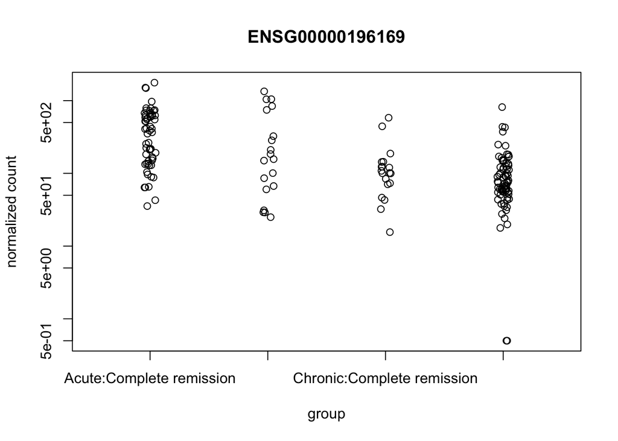

```r
#Find the top gene and plot it with normalized counts
topGene <- rownames(res_SRP059172)[which.min(res_SRP059172$padj)]
plotCounts(dds_SRP059172, gene = topGene, intgroup=c("group", "response"))
```

```r
geneCounts <- plotCounts(dds_SRP059172, gene = topGene, intgroup = c("group", "response"),
                         returnData = TRUE)
```

Figure 1. Top Gene: Normalized counts grouped by acute/chronic and remission/reinfection.

### VST

Transform DESeq (dds) with VST and show the change in a plot. Since there are 169 samples in this dataset, we can feel comfortable using VST to transform the brucellosis data and remove some data points. We expect the dots to change from very dispersed to less and the bottom left quardrent of the plot to disappear.

```r
#Transform with VST
vsd_SRP059172<-vst(dds_SRP059172, blind=FALSE)

#Take a look at the transformed data
head(assay(vsd_SRP059172), 3)
```

[output not shown]

[output cut: 81 more lines]

```
## ENSG00000000003   5.459488   4.905224   5.887552   6.187122   6.030020
## ENSG00000000005   4.905224   4.905224   4.905224   4.905224   4.905224
## ENSG00000000419   9.747306   9.202741   9.816150   9.786094   9.844292
##                 SRR2052670 SRR2052669 SRR2052668 SRR2052667 SRR2052666
## ENSG00000000003   6.237616   5.955034   5.662058   6.250711   4.905224
## ENSG00000000005   4.905224   4.905224   4.905224   4.905224   4.905224
## ENSG00000000419   9.678943   9.463894   9.728326   9.760745   8.809098
##                 SRR2052665 SRR2052664 SRR2052663 SRR2052662 SRR2052661
## ENSG00000000003   5.468242   4.905224   6.031897   5.649853   5.686001
## ENSG00000000005   4.905224   4.905224   4.905224   4.905224   4.905224
## ENSG00000000419   9.565248  10.557358  10.044646   9.405088   9.618961
##                 SRR2052660 SRR2052659 SRR2052658 SRR2052657
## ENSG00000000003   5.549721   4.905224   5.477018   5.489041
## ENSG00000000005   4.905224   4.905224   4.905224   4.905224
## ENSG00000000419   9.790895   9.606277   9.757906   9.811558
```

```r
colData(vsd_SRP059172)
```

```
## DataFrame with 169 rows and 25 columns
##                project      sample  experiment         run
##            <character> <character> <character> <character>
## SRR2052702   SRP059172   SRS954288  SRX1050128  SRR2052702
## SRR2052701   SRP059172   SRS954289  SRX1050127  SRR2052701
## SRR2052700   SRP059172   SRS954290  SRX1050126  SRR2052700
## SRR2052699   SRP059172   SRS954291  SRX1050125  SRR2052699
## SRR2052698   SRP059172   SRS954292  SRX1050124  SRR2052698
## ...                ...         ...         ...         ...
## SRR2052661   SRP059172   SRS954452  SRX1050087  SRR2052661
## SRR2052660   SRP059172   SRS954453  SRX1050086  SRR2052660
## SRR2052659   SRP059172   SRS954454  SRX1050085  SRR2052659
## SRR2052658   SRP059172   SRS954455  SRX1050084  SRR2052658
## SRR2052657   SRP059172   SRS954456  SRX1050083  SRR2052657
##            read_count_as_reported_by_sra reads_downloaded
##                                <integer>        <integer>
## SRR2052702                       9114489          9114489
## SRR2052701                       8710667          8710667
## SRR2052700                       8233416          8233416
## SRR2052699                       7463990          7463990
## SRR2052698                       9254570          9254570
## ...                                  ...              ...
## SRR2052661                       7842895          7842895
## SRR2052660                       6664630          6664630
## SRR2052659                       8027046          8027046
## SRR2052658                       8292498          8292498
## SRR2052657                       7632335          7632335
##            proportion_of_reads_reported_by_sra_downloaded paired_end
##                                                 <numeric>  <logical>
## SRR2052702                                              1      FALSE
## SRR2052701                                              1      FALSE
## SRR2052700                                              1      FALSE
## SRR2052699                                              1      FALSE
## SRR2052698                                              1      FALSE
## ...                                                   ...        ...
## SRR2052661                                              1      FALSE
## SRR2052660                                              1      FALSE
## SRR2052659                                              1      FALSE
## SRR2052658                                              1      FALSE
## SRR2052657                                              1      FALSE
```

[output cut: 76 more lines]

```
## SRR2052658                group: Brucellosis,subgroup: Group 1,history of brucellosis: Acute brucellosis,...
## SRR2052657                group: Brucellosis,subgroup: Group 1,history of brucellosis: Acute brucellosis,...
##               group           response        sizeFactor replaceable
##            <factor>           <factor>         <numeric>   <logical>
## SRR2052702  Chronic Complete remission  1.12545942692032        TRUE
## SRR2052701    Acute Complete remission  1.08688247370803        TRUE
## SRR2052700    Acute Complete remission  1.04187158572122        TRUE
## SRR2052699    Acute Complete remission  1.02358162584089        TRUE
## SRR2052698    Acute        Reinfection 0.996971453788556        TRUE
## ...             ...                ...               ...         ...
## SRR2052661    Acute Complete remission  1.11198922456809        TRUE
## SRR2052660  Chronic Complete remission 0.986796127354808        TRUE
## SRR2052659    Acute        Reinfection 0.918612488623625        TRUE
## SRR2052658    Acute Complete remission  1.04843630507487        TRUE
## SRR2052657    Acute Complete remission  1.00514187792019        TRUE
```

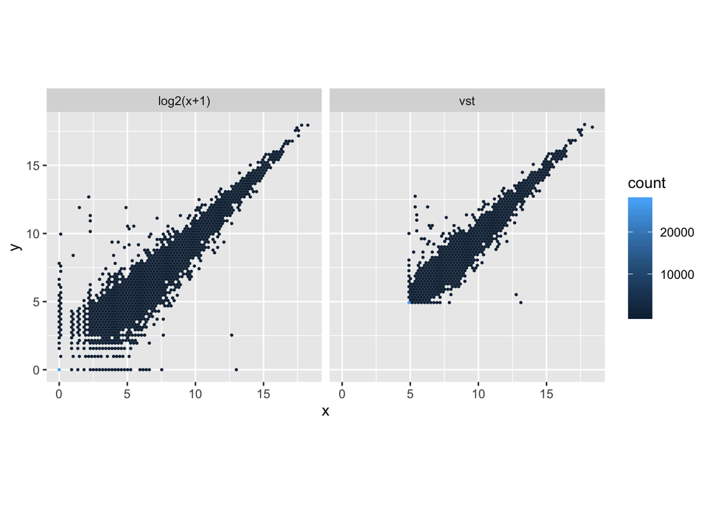

```r
#estimate size factors of dds using the median ration method
dds_SRP059172<-estimateSizeFactors(dds_SRP059172)
#create data frame for vst vs dds comparison plot
df_dds_vst<-bind_rows(as_data_frame(log2(counts(dds_SRP059172, normalized=TRUE)[,1:2]+1))%>%mutate(transformation="log2(x+1)"),as_data_frame(assay(vsd_SRP059172)[,1:2])%>%mutate(transformation="vst"))
#Make labels for vst plot
colnames(df_dds_vst)[1:2]<-c("x","y")
#plot the vst vs the dds data. As you can see in the plot, there is a big change in the vst plot that allows the data to become more uniform and less dispersed. VST has part of the bottom left quartile (short reads) taken out to decrease variability because we have enough samples (169) without it interferring with the experiment.
ggplot(df_dds_vst, aes(x=x, y=y))+geom_hex(bins=80)+coord_fixed()+facet_grid(.~transformation)
```

Figure 2. DDS vs VST: Normalized counts transformed with VST (right) versus not transformed (left).

The data points have become less dispersed, but they could do even better, and the bottom left corner of the plot does not have any data points anymore.

### PCA

Plot Principal Components Analysis of the vst transformed data grouped by diagnosis acute or chronic. We expect a large separation, two clusters, one for chronic and one for acute brucellosis.

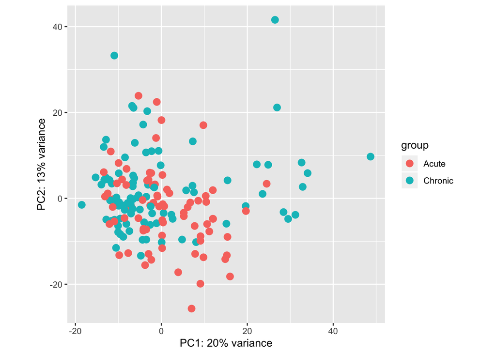

```r
#plot PCA and split it into two groups, those with chronic brucellosis and those with acute brucellosis. We see here that the acute are on the left side only  while the chronic are all over the plot.
plotPCA(vsd_SRP059172, intgroup=c("group"))
```

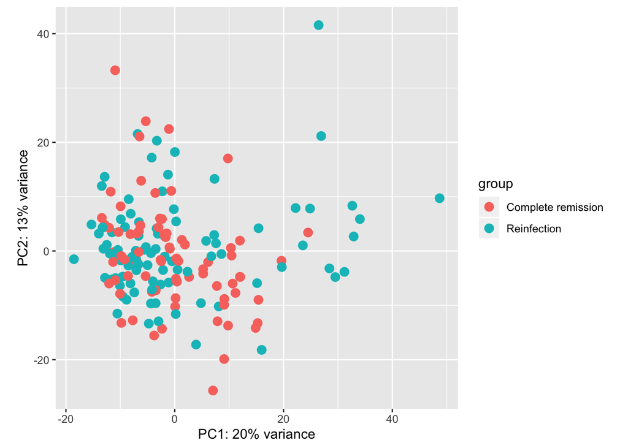

```r
plotPCA(vsd_SRP059172, intgroup=c("response"))
```

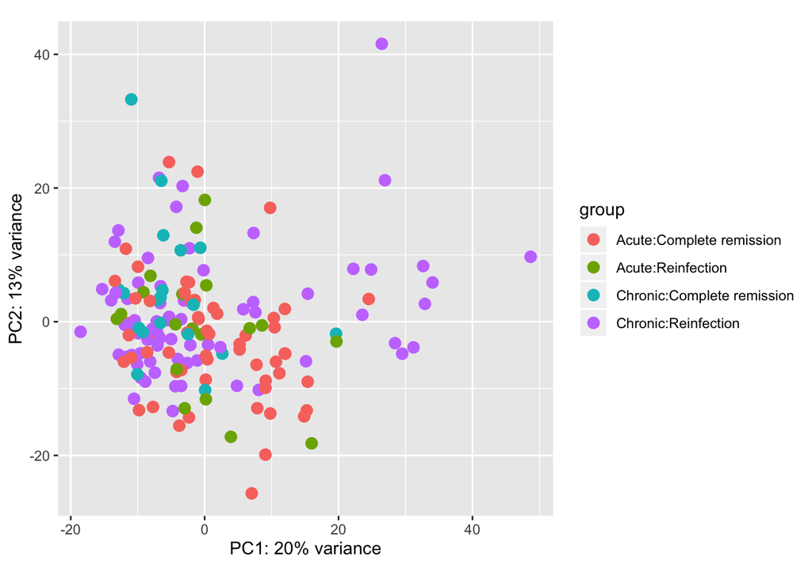

```r
plotPCA(vsd_SRP059172, intgroup=c("group", "response"))
```

Figure 3. a. PCA plot of chronic/acute. b. PCA plot of remission/reinfection. c. PCA plot of both chronic/acute and remission/reinfection.

These first two plots show a mild separation between acute and chronic with acute staying on the left hand side and chronic on the right and the left. The third plot shows chronic reinfection are the main dots that are on the right hand side of the plot.

### MA Plot

Create MA plot of the dds results data for the brucellosis dataset. This plot visualizes the differences between measurements taken in acute and chronic samples, by transforming the data onto M (log ratio) and A (mean average) scales, then plotting these values. Use lfcShrink with type apeglm to shrink the log2 fold changes for the diagnosis comparison. We expect to see a large change after shrinking the log fold changes and the gray area of the plot to closely surround the midline.

```r
#MA plot with log 2 fold changes shrunk with apeglm
#dds_SRP059172<- DESeq(dds_SRP059172)
res_SRP059172 <- lfcShrink(dds_SRP059172, coef="group_Chronic_vs_Acute", type="apeglm")
```

```
## using 'apeglm' for LFC shrinkage. If used in published research, please cite:
##     Zhu, A., Ibrahim, J.G., Love, M.I. (2018) Heavy-tailed prior distributions for
##     sequence count data: removing the noise and preserving large differences.
##     Bioinformatics. https://doi.org/10.1093/bioinformatics/bty895
```

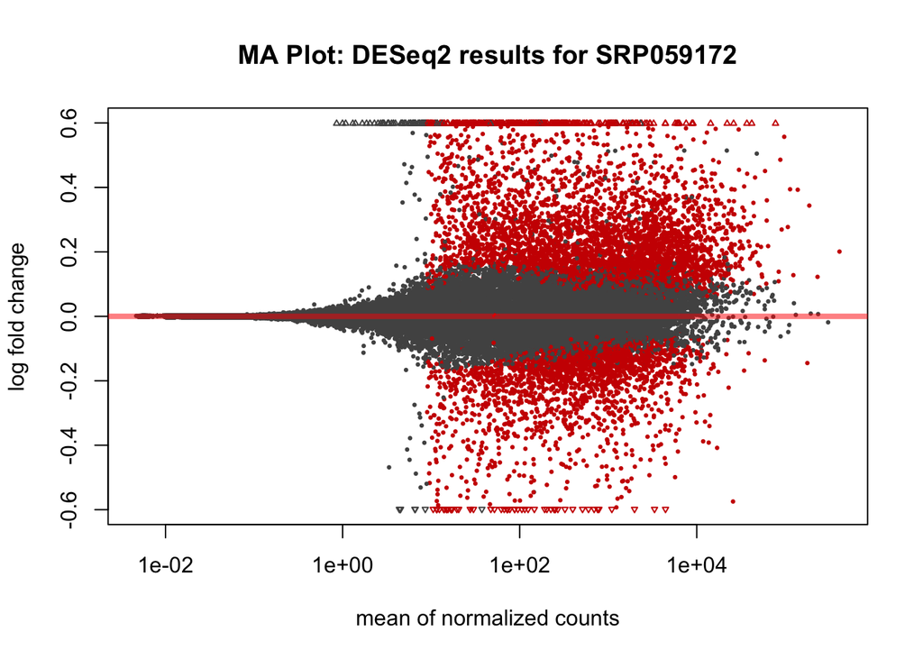

```r
MAplot_group<-plotMA(res_SRP059172, main="MA Plot: DESeq2 results for SRP059172")
```

Figure 4. MA Plot of results after shrinking log2 fold changes. Red dots are the genes with adjusted p values below threshold.

This is an MA-plot of changes from being diagnosed with either acute or chronic brucellosis. The log2 fold change for a particular comparison is plotted on the y-axis and the average of the counts normalized by size factor is shown on the x-axis. Each gene is represented with a dot. Genes with an adjusted p value below a threshold (here 0.1, the default) are shown in red. The gray area of the plot could be surrounding the midline tighter than it currently is for a better fit.

### Heatmap

In the following code, we create a heatmap using the top 10 genes. We are looking at how the genes vary from the average across samples. Diagnosis and response to treatment are shown in the labels and in the top 2 rows. We expect to see a difference between chronic and acute gene expression.

```
## Found more than one class "unit" in cache; using the first, from namespace 'ggbio'
```

```
## Also defined by 'hexbin'
```

```
## Found more than one class "unit" in cache; using the first, from namespace 'ggbio'
```

```
## Also defined by 'hexbin'
```

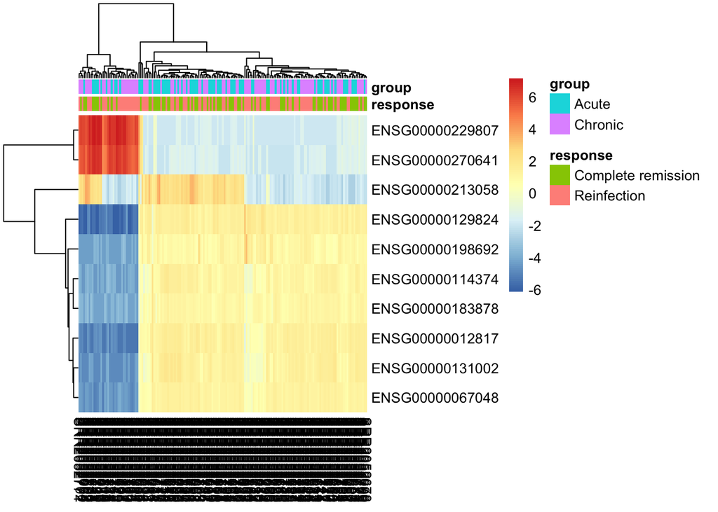

```r
topVarGenes <- head(order(rowVars(assay(vsd_SRP059172)), decreasing = TRUE), 10)

mat  <- assay(vsd_SRP059172)[ topVarGenes, ]
mat  <- mat - rowMeans(mat)
anno <- as.data.frame(colData(vsd_SRP059172)[, c("response","group")])
pheatmap(mat, annotation_col = anno)
```

Figure 5. Heapmap of top 10 genes with acute/chronic and remission/reinfection row labels at the top.

In the following plot we should see items that protect the body from bacteria like brucella and we should see some stress related items.

```r
#GO enrichment
## Remember that res had ENSEMBL IDs for the genes
head(rownames(res_SRP059172))
```

```
## [1] "ENSG00000000003" "ENSG00000000005" "ENSG00000000419" "ENSG00000000457"
## [5] "ENSG00000000460" "ENSG00000000938"
```

```
## wrong orderBy parameter; set to default `orderBy = "x"`
```

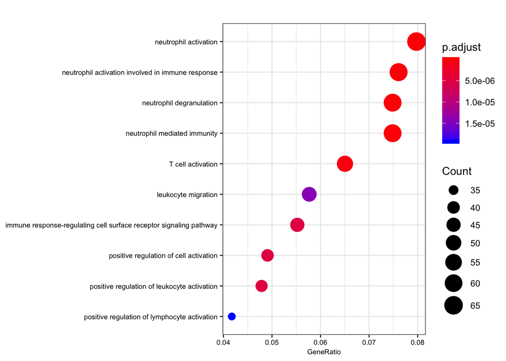

```r
## Perform enrichment analysis for Biological Process (BP)
enrich_go_SRP059172 <- enrichGO(
  gene = rownames(res_SRP059172)[res_SRP059172$padj < 0.001],
  OrgDb = org.Hs.eg.db, keyType = "ENSEMBL", ont = "BP",
  pAdjustMethod = "BH", pvalueCutoff = 0.01, qvalueCutoff = 0.05,
  universe = rownames(res_SRP059172))
## Visualize enrichment results. It show high count of t cell activation.
dotplot(enrich_go_SRP059172, font.size = 7)
```

Figure 6. GO Enrichment Plot with size showing count and color showing p value.

### References

Liu W, Dong H, Li J, et al. RNA-seq reveals the critical role of OtpR in regulating Brucella melitensis metabolism and virulence under acidic stress. Sci Rep. 2015;5:10864. Published 2015 Aug 5. doi:10.1038/srep10864

Zhang X, Ren J, Li N, Liu W, Wu Q. Disruption of the BMEI0066 gene attenuates the virulence of Brucella melitensis and decreases its stress tolerance. Int J Biol Sci. 2009;5(6):570–577. Published 2009 Sep 1. doi:10.7150/ijbs.5.570

Sternon JF, Godessart P, Gonçalves de Freitas R, et al. Transposon Sequencing of Brucella abortus Uncovers Essential Genes for Growth In Vitro and Inside Macrophages. Infect Immun. 2018;86(8):e00312-18. Published 2018 Jul 23. doi:10.1128/IAI.00312-18

Brambila-Tapia AJ, Armenta-Medina D, Rivera-Gomez N, Perez-Rueda E. Main functions and taxonomic distribution of virulence genes in Brucella melitensis 16 M. PLoS One. 2014;9(6):e100349. Published 2014 Jun 25. doi:10.1371/journal.pone.0100349

DelVecchio VG, Kapatral V, Redkar RJ, et al. The genome sequence of the facultative intracellular pathogen Brucella melitensis. Proc Natl Acad Sci U S A. 2002;99(1):443–448. doi:10.1073/pnas.221575398

Li X, Wang Q, Gong J, Huang F, Feng J, Liang J, Hu B. Rare Meningitis and Epileptic Seizure Infected with Brucella melitensis: a Case Report. Clin Lab. 2019;65(11). doi: 10.7754/Clin.Lab.2019.180624.

Kawakami N1, Wakai Y1, Saito K1, Imaoka K2. Chronic Brucellosis in Japan. Intern Med. 2019;58(21):3179-3183. doi: 10.2169/internalmedicine.2961-19. Epub 2019 Nov 1.

Suvak B1, Dulger AC1, Karadas S2, Gonullu H3, Bayram Y4, Gonullu E5, Batur A6, Aykaç MC2, Gunduz AM7, Aytemiz E8, Guducuoglu H4. Brucellosis-related acute pancreatitis: A rare complication of a universal disease. J Int Med Res. 2016 Feb;44(1):131-5. doi: 10.1177/0300060515583078. Epub 2015 Dec 7.

Alavi, S. M., & Alavi, L. (2013). Treatment of brucellosis: a systematic review of studies in recent twenty years. Caspian journal of internal medicine, 4(2), 636–641.